# Lab2

### Basics of ggplot

The whole package of ggplot has seven aspects, but we are only going to focus on the first three:

- Data
- Aesthetics
- Geometries
- Facets
- Statistics
- Coordinates
- Themes

Think about each aspect as a layer of your plot.

The first layer is your data—which is obvious, since those are what we are going to plot.

The second layer is aesthetics or mapping, which is how you want to plot the data—variables to use. It is specified inside aes() below—anything inside aes() depends on your data.

Finally, you decide what kind of plot you want for your data, such as scatterplot, histogram, box plot, bar plot, etc. Geometries are chosen via a series of geom functions, such as geom_point() for scatterplots.

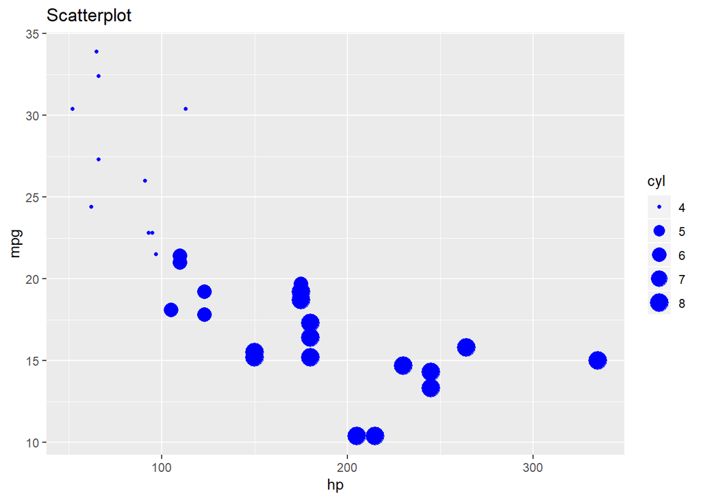

```r
ggplot(data = mtcars, aes(x = hp, y = mpg, size = cyl)) + geom_point(color = 'blue') + ggtitle("Scatterplot")
```

### Examples

#### Scatterplot

Scatterplots are best for showing relationship between two numeric variables, as shown above.

#### Histogram

Histograms are used to display the distribution of numeric variables. It only needs one variable to show. You can adjust the plot with bin or bin width.

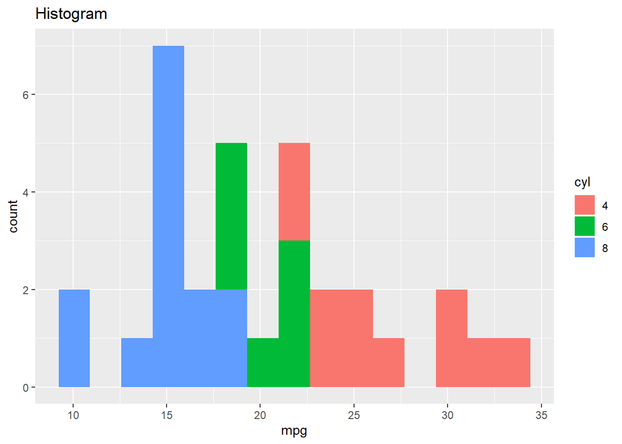

```r
mtcars$cyl = as.character(mtcars$cyl)
ggplot(data = mtcars, aes(x = mpg, fill = cyl)) + geom_histogram(bins = 15) + ggtitle("Histogram")
```

#### Dot plot and box plot

Dot plots are useful when you want to show the distribution of either numeric or categorical variables.

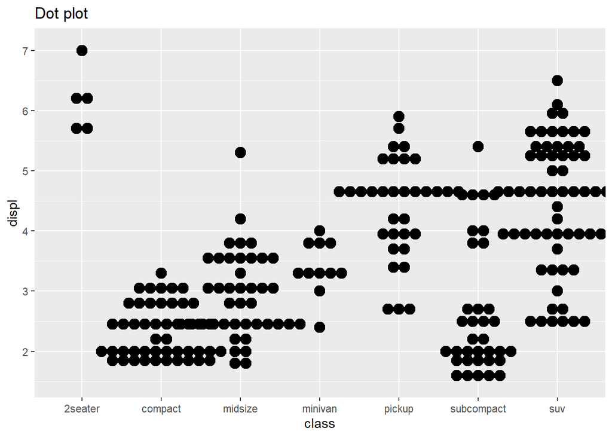

```r
ggplot(mpg, aes(x = class, y = displ)) +
  geom_dotplot(binaxis='y', stackdir='center') + ggtitle("Dot plot")
```

Box plots are another way of showing distribution of numeric variables, with 1st and 3rd quartiles represented by the verge of box.

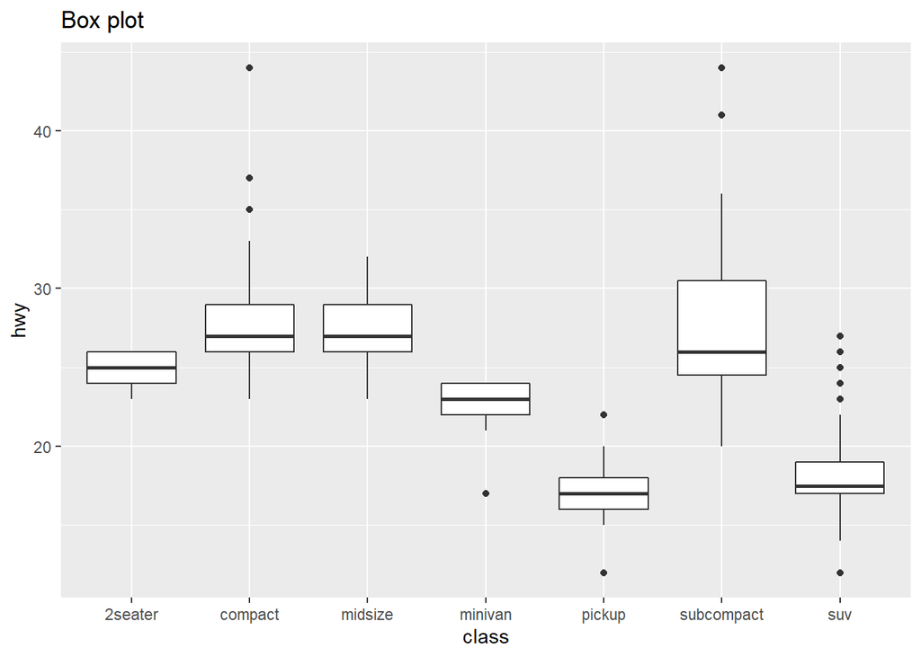

```r
ggplot(mpg, aes(x = class, y = hwy)) +
  geom_boxplot() + ggtitle("Box plot")
```

#### Bar plot

A bar plot illustrates data in rectangular bars with length of the bar proportional to the value of the variable.

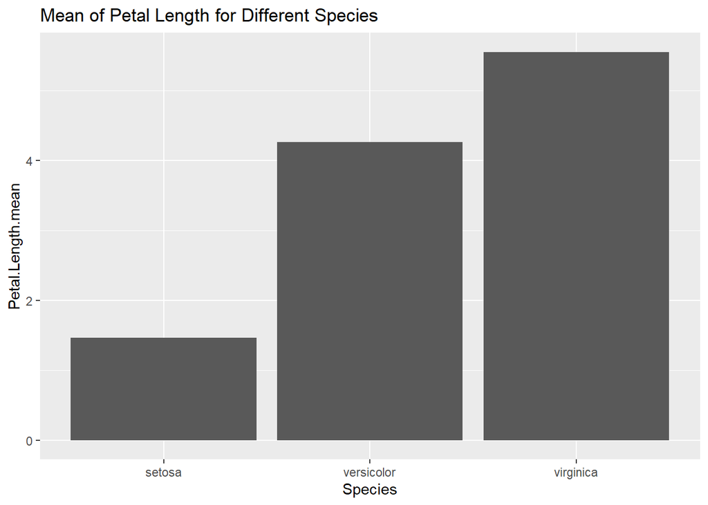

```r
library(dplyr)
species_mean = iris %>% group_by(Species) %>%
  summarise(Petal.Length.mean  = mean(Petal.Length))

ggplot(data=species_mean, aes(x=Species, y=Petal.Length.mean)) +
  geom_bar(stat="identity") + ggtitle("Mean of Petal Length for Different Species")
```

#### Density plot

Density plots are continuous version of histogram. They convey the same information—distribution of numeric variables. Instead of bins, density plots use a kernel density estimate (smooth curve) to represent the distribution. If you compare the density plot with the histogram, you can see they are showing the same thing.

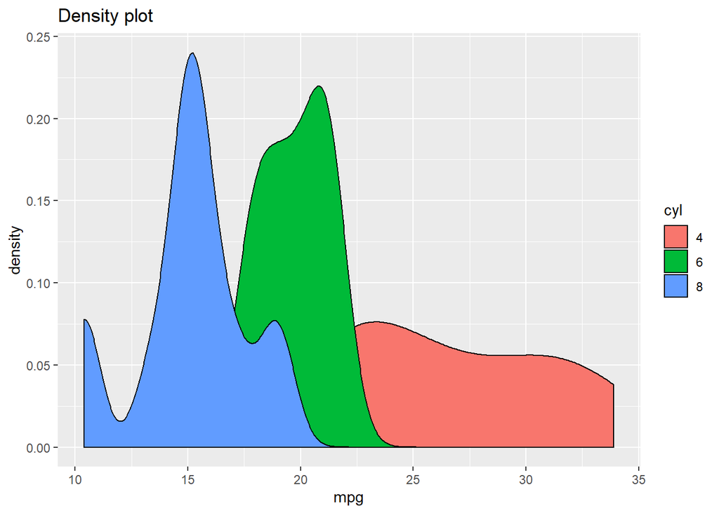

```r
ggplot(data = mtcars, aes(x = mpg, fill = cyl)) + geom_density() + ggtitle("Density plot")
```

**Tips:** if you don’t know something about a function or a package, use ? followed by your target in the console to look up the documents, or simply just google it.

## Exercises:

### 1

Find two datasets in forms of .csv and .xlsx online and read them into R. Show the first and last few rows and summary of data. Here is a link to find datasets: https://www.kaggle.com/datasets.

### 2

Use one of the datasets you just read in, plot a scatterplot for two continuous variables in it and describe their apparent relationship. Comment on the relationship, does it make sense?

### 3

Choose a continuous variable in the datasets and plot both density plot and histogram in one graph. Hint: ggplot plots can be added on top of each other by using ‘+’ sign.

### 4

Choose a continuous variable and a categorical variable in one of the datasets. Calculate the medians of that continuous variable for each category and make a bar plot for these medians.

### 5

Choose a continuous variable and a categorical variable in one of the datasets. Make a box plot for that continuous variable across all categories. Do the same thing for a dot plot and show them in one graph.

Reference

- R documents (ggplot2, qplot)
- Dataset *Elevator Data for Day 1.xlsx* is from Dr. Smith

Acknowledgments: This assignment has been adapted from the labs created by Kelly Moran for STA101, which were adapted for OpenIntro by Andrew Bray and Mine Çetinkaya-Rundel from a lab written by Mark Hansen of UCLA Statistics.